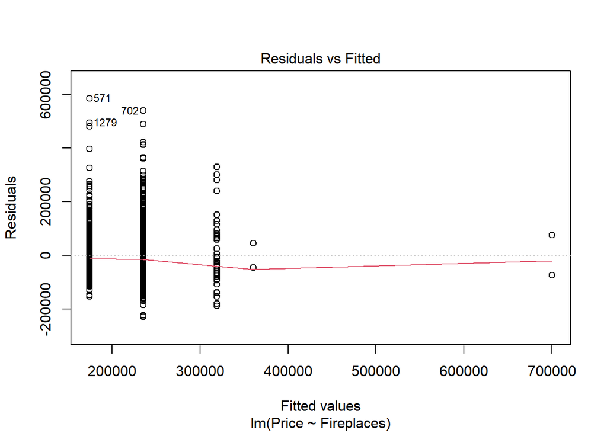

```r
plot(model7, which=1)
```

##Box plot of house price by Bathrooms & Analysis of Price ~ Bathrooms

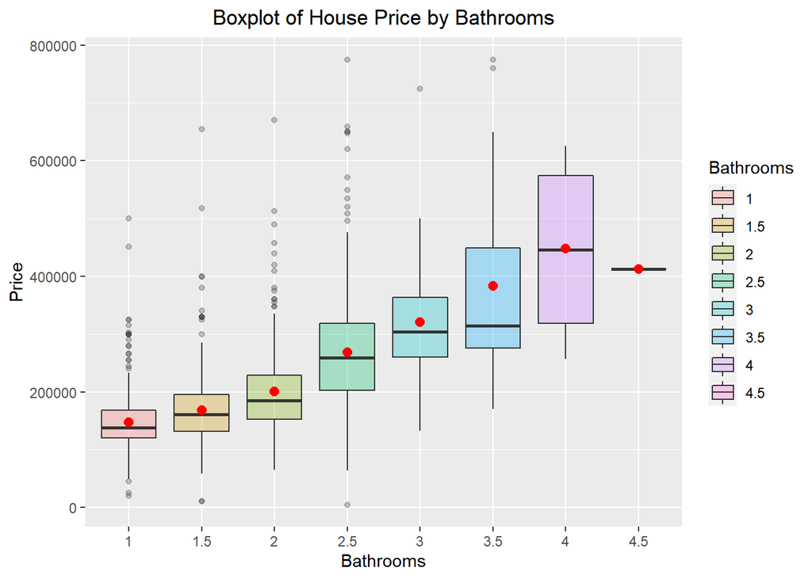

```r
ggplot(HP, aes(x=Bathrooms, y=Price, fill=Bathrooms)) +
  geom_boxplot(alpha=0.3) +
  stat_summary(fun.y=mean, geom="point", shape=20, size=4, color="red", fill="red")+
  ggtitle("Boxplot of House Price by Bathrooms")+
  theme(plot.title = element_text(hjust = 0.5))
```

```r
model8=lm(Price~Bathrooms,data=HP)
summary(model8)
```

```
##
## Call:
## lm(formula = Price ~ Bathrooms, data = HP)
##
## Residuals:
##     Min      1Q  Median      3Q     Max
## -263345  -46979   -9345   31655  506655
##
## Coefficients:
##              Estimate Std. Error t value             Pr(>|t|)
## (Intercept)    147751       4316  34.231 < 0.0000000000000002 ***
## Bathrooms1.5    20278       5558   3.649             0.000272 ***
## Bathrooms2      52861       6507   8.124 0.000000000000000849 ***
## Bathrooms2.5   120594       5452  22.118 < 0.0000000000000002 ***
## Bathrooms3     173228      11288  15.346 < 0.0000000000000002 ***
## Bathrooms3.5   235362      13706  17.172 < 0.0000000000000002 ***
## Bathrooms4     300699      27931  10.766 < 0.0000000000000002 ***
## Bathrooms4.5   264749      78172   3.387             0.000723 ***
## ---
## Signif. codes:  0 '***' 0.001 '**' 0.01 '*' 0.05 '.' 0.1 ' ' 1
##
## Residual standard error: 78050 on 1723 degrees of freedom
## Multiple R-squared:  0.3748, Adjusted R-squared:  0.3723
## F-statistic: 147.6 on 7 and 1723 DF,  p-value: < 0.00000000000000022
```

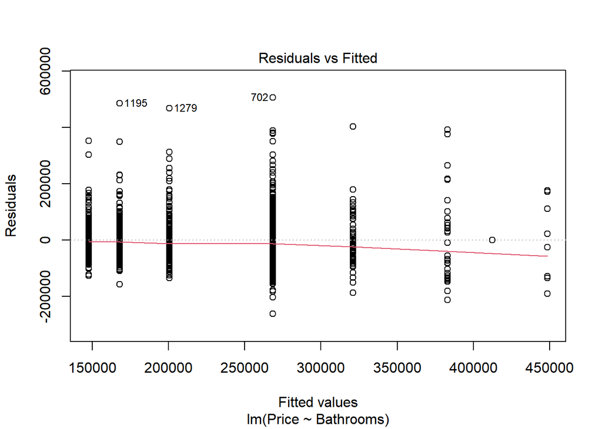

```r
plot(model8, which=1)
```

#Box plot of house price by Rooms & Analysis of Price ~ Rooms

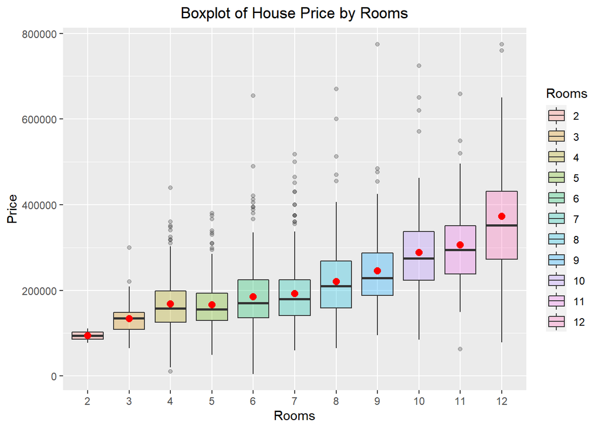

```r
ggplot(HP, aes(x=Rooms, y=Price, fill=Rooms)) +
  geom_boxplot(alpha=0.3) +
  stat_summary(fun.y=mean, geom="point", shape=20, size=4, color="red", fill="red")+
  ggtitle("Boxplot of House Price by Rooms")+
  theme(plot.title = element_text(hjust = 0.5))
```

```r
model9=lm(Price~Rooms,data=HP)
summary(model9)
```

```
##
## Call:
## lm(formula = Price ~ Rooms, data = HP)
##
## Residuals:
##     Min      1Q  Median      3Q     Max
## -294719  -50850  -11450   36525  529721
##
## Coefficients:
##             Estimate Std. Error t value   Pr(>|t|)
## (Intercept)    94500      57878   1.633   0.102708
## Rooms3         39656      58597   0.677   0.498651
## Rooms4         73745      58194   1.267   0.205242
## Rooms5         71950      58136   1.238   0.216032
## Rooms6         90814      58112   1.563   0.118300
## Rooms7         97329      58068   1.676   0.093895 .
## Rooms8        126097      58102   2.170   0.030124 *
## Rooms9        150779      58285   2.587   0.009765 **
## Rooms10       194067      58287   3.329   0.000888 ***
## Rooms11       211414      58677   3.603   0.000323 ***
## Rooms12       278719      58625   4.754 0.00000216 ***
## ---
## Signif. codes:  0 '***' 0.001 '**' 0.01 '*' 0.05 '.' 0.1 ' ' 1
##
## Residual standard error: 81850 on 1720 degrees of freedom
## Multiple R-squared:  0.3137, Adjusted R-squared:  0.3097
## F-statistic: 78.61 on 10 and 1720 DF,  p-value: < 0.00000000000000022
```

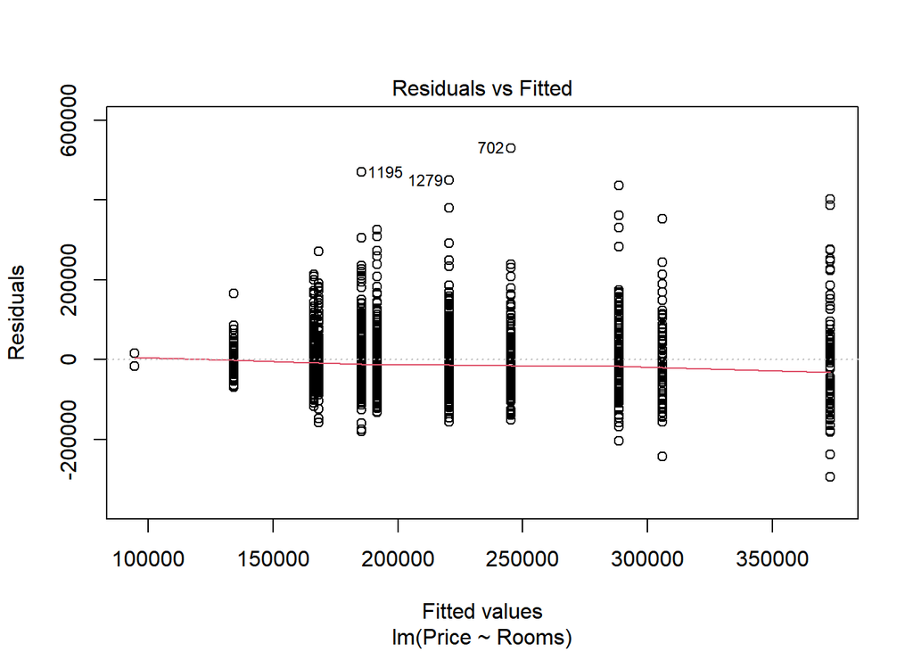

```r
plot(model9, which=1)
```

#Boxplot of House Price by Waterfront and t-test for waterfront

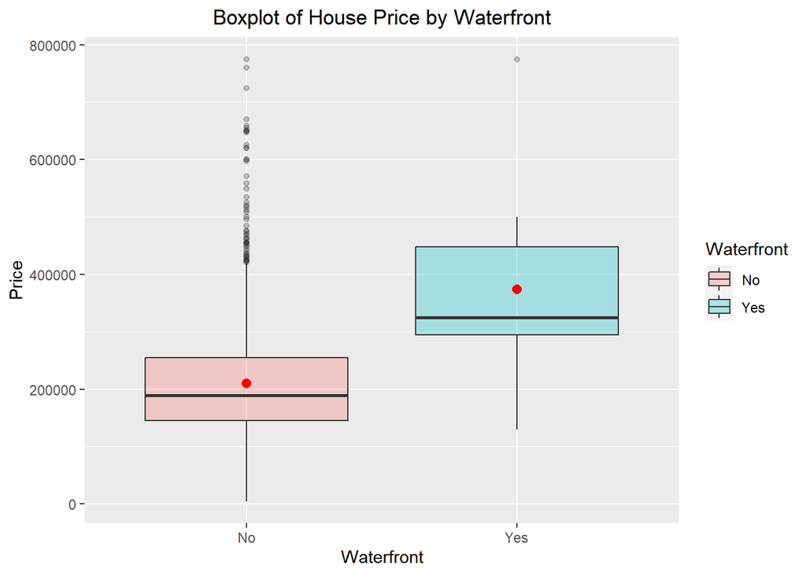

```r
ggplot(HP, aes(x=Waterfront, y=Price, fill=Waterfront)) +
  geom_boxplot(alpha=0.3) +
  stat_summary(fun.y=mean, geom="point", shape=20, size=4, color="red", fill="red")+
  ggtitle("Boxplot of House Price by Waterfront")+
  theme(plot.title = element_text(hjust = 0.5))
```

#Hypothesis test #alpha=0.05 #null hypothesis: There is no significant difference between means of homes where waterfront is present and where waterfront is absent. #alternative hypothesis: There is significant difference between means of homes where waterfront is present and where waterfront is absent.

```r
tapply(Price, Waterfront, mean)
```

```
##        0        1
## 210291.8 373991.7
```

```r
t.test(Price~Waterfront)
```

```
##
##  Welch Two Sample t-test
##
## data:  Price by Waterfront
## t = -4.0825, df = 14.095, p-value = 0.001105
## alternative hypothesis: true difference in means is not equal to 0
## 95 percent confidence interval:
##  -249647.61  -77752.13
## sample estimates:
## mean in group 0 mean in group 1
##        210291.8        373991.7
```

#Boxplot of House Price by New Construction and t-test for new.construct

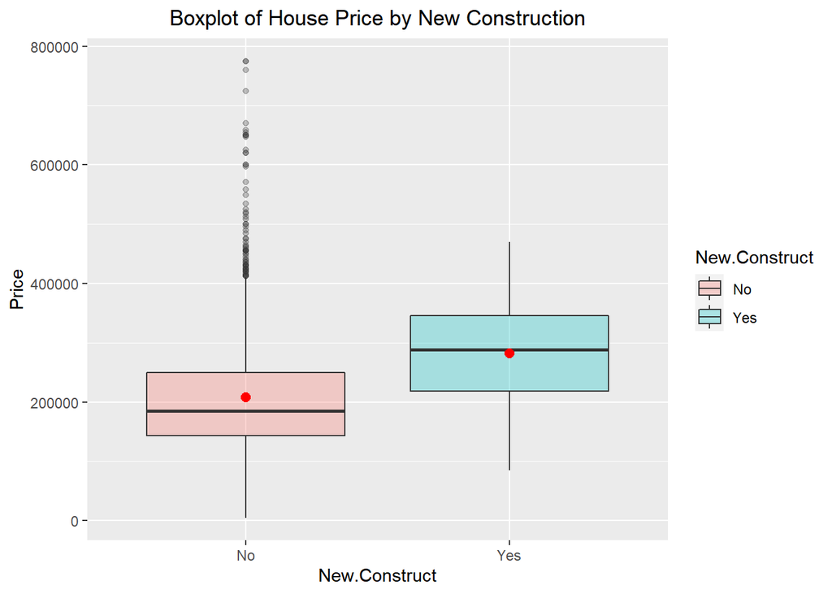

```r
ggplot(HP, aes(x=New.Construct, y=Price, fill=New.Construct)) +
  geom_boxplot(alpha=0.3) +
  stat_summary(fun.y=mean, geom="point", shape=20, size=4, color="red", fill="red")+
  ggtitle("Boxplot of House Price by New Construction")+
  theme(plot.title = element_text(hjust = 0.5))
```

#Hypothesis test #alpha=0.05 #null hypothesis: There is no significant difference between means of new constructed homes and old homes. #alternative hypothesis: There is significant difference between means of new constructed homes and old homes.

```r
tapply(Price, New.Construct, mean)
```

```
##        0        1
## 208244.7 282306.8
```

```r
t.test(Price~New.Construct)
```

```
##
##  Welch Two Sample t-test
##
## data:  Price by New.Construct
## t = -7.6912, df = 91.03, p-value = 0.00000000001659
## alternative hypothesis: true difference in means is not equal to 0
## 95 percent confidence interval:
##  -93189.84 -54934.41
## sample estimates:
## mean in group 0 mean in group 1
##        208244.7        282306.8
```

#Boxplot of House Price by Central Air and t-test for Central.Air

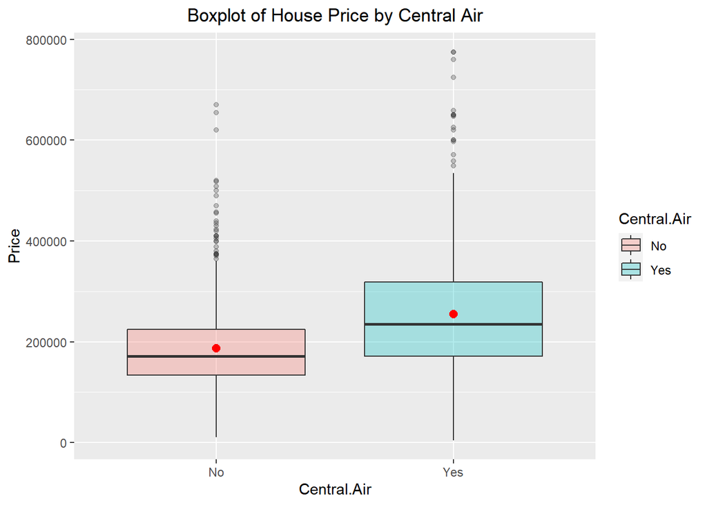

```r
ggplot(HP, aes(x=Central.Air, y=Price, fill=Central.Air)) +
  geom_boxplot(alpha=0.3) +
  stat_summary(fun.y=mean, geom="point", shape=20, size=4, color="red", fill="red")+
  ggtitle("Boxplot of House Price by Central Air")+
  theme(plot.title = element_text(hjust = 0.5))
```

#Hypothesis test #alpha=0.05 #null hypothesis: There is no significant difference between means of homes where Central Air present and the homes where central air not present. #alternative hypothesis: There is significant difference between means of homes where Central Air present and the homes where central air not present.

```r
tapply(Price, Central.Air, mean)
```

```
##        0        1
## 186684.9 254903.8
```

```r
t.test(Price~Central.Air)
```

```
##
##  Welch Two Sample t-test
##
## data:  Price by Central.Air
## t = -13.387, df = 987.09, p-value < 0.00000000000000022
## alternative hypothesis: true difference in means is not equal to 0
## 95 percent confidence interval:
##  -78219.22 -58218.46
## sample estimates:
## mean in group 0 mean in group 1
##        186684.9        254903.8
```

#ANOVA test based on fuel type

```r
tapply(Price, Fuel.Type, mean)
```

```
##  Electric       Gas       Oil   Unknown
## 164937.57 228562.38 188734.40  97006.25
```

```r
anova<-aov(Price~Fuel.Type)
modelaov1 <- lm(Price~Fuel.Type)
summary(anova)
```

```
##               Df         Sum Sq      Mean Sq F value              Pr(>F)
## Fuel.Type      3  1195429652300 398476550767   44.13 <0.0000000000000002 ***
## Residuals   1727 15594921381251   9030064494
## ---
## Signif. codes:  0 '***' 0.001 '**' 0.01 '*' 0.05 '.' 0.1 ' ' 1
```

```r
coef(modelaov1)
```

```
##      (Intercept)     Fuel.TypeGas     Fuel.TypeOil Fuel.TypeUnknown
##        164937.57         63624.81         23796.83        -67931.32
```

#ANOVA test based on heat type

```r
tapply(Price, Heat.Type, mean)
```

```
##  Electric   Hot Air Hot Water   Unknown
## 161888.63 226382.62 209132.46  97006.25
```

```r
anova<-aov(Price~Heat.Type)
modelaov2 <- lm(Price~Heat.Type)
summary(anova)
```

```
##               Df         Sum Sq      Mean Sq F value              Pr(>F)
## Heat.Type      3  1052815863245 350938621082   38.51 <0.0000000000000002 ***
## Residuals   1727 15737535170305   9112643411
## ---
## Signif. codes:  0 '***' 0.001 '**' 0.01 '*' 0.05 '.' 0.1 ' ' 1
```

```r
coef(modelaov2)
```

```
##        (Intercept)   Heat.TypeHot Air Heat.TypeHot Water   Heat.TypeUnknown
##          161888.63           64493.99           47243.83          -64882.38
```

#ANOVA test based on Sewer type

```r
tapply(Price, Sewer.Type, mean)
```

```
##  Private   Public  Unknown
## 199597.0 216375.2 250952.3
```

```r
anova<-aov(Price~Sewer.Type)
modelaov3 <- lm(Price~Sewer.Type)
summary(anova)
```

```
##               Df         Sum Sq     Mean Sq F value  Pr(>F)
## Sewer.Type     2   119121637669 59560818834   6.174 0.00213 **
## Residuals   1728 16671229395882  9647702197
## ---
## Signif. codes:  0 '***' 0.001 '**' 0.01 '*' 0.05 '.' 0.1 ' ' 1
```

```r
coef(modelaov3)
```

```
##       (Intercept)  Sewer.TypePublic Sewer.TypeUnknown
##         199597.01          16778.16          51355.33
```

#Multiple Regression

```r
modelReg1<-lm(Price~ Land.Value + Living.Area + Bathrooms + Rooms, data=HP)
summary(modelReg1)
```

```
##
## Call:
## lm(formula = Price ~ Land.Value + Living.Area + Bathrooms + Rooms,
##     data = HP)
##
## Residuals:
##     Min      1Q  Median      3Q     Max
## -220736  -35720   -6107   28504  457895
##
## Coefficients:
##                 Estimate  Std. Error t value             Pr(>|t|)
## (Intercept)  24825.25652 43014.12234   0.577               0.5639
## Land.Value       0.95881     0.04629  20.712 < 0.0000000000000002 ***
## Living.Area     67.46644     4.68388  14.404 < 0.0000000000000002 ***
## Bathrooms1.5  1677.97579  4491.69855   0.374               0.7088
## Bathrooms2   26553.62811  5267.60117   5.041      0.0000005123389 ***
## Bathrooms2.5 32673.01750  5553.74474   5.883      0.0000000048343 ***
## Bathrooms3   49127.70068  9916.16941   4.954      0.0000007976127 ***
## Bathrooms3.5 81669.26773 12460.23993   6.554      0.0000000000737 ***
## Bathrooms4   40977.90717 24100.84532   1.700               0.0893 .
## Bathrooms4.5 15921.28166 61701.91746   0.258               0.7964
## Rooms3        9721.93717 43478.88320   0.224               0.8231
## Rooms4       18230.61419 43209.73475   0.422               0.6731
## Rooms5       11032.54585 43198.55445   0.255               0.7985
## Rooms6       19219.74637 43184.54016   0.445               0.6563
## Rooms7       14479.55576 43176.74178   0.335               0.7374
## Rooms8       20716.82258 43259.57426   0.479               0.6321
## Rooms9       10091.37351 43507.16571   0.232               0.8166
## Rooms10      25262.03373 43612.66065   0.579               0.5625
## Rooms11      24218.91394 44021.46186   0.550               0.5823
## Rooms12      24528.64878 44314.69881   0.554               0.5800
## ---
## Signif. codes:  0 '***' 0.001 '**' 0.01 '*' 0.05 '.' 0.1 ' ' 1
##
## Residual standard error: 60630 on 1711 degrees of freedom
## Multiple R-squared:  0.6254, Adjusted R-squared:  0.6213
## F-statistic: 150.4 on 19 and 1711 DF,  p-value: < 0.00000000000000022
```

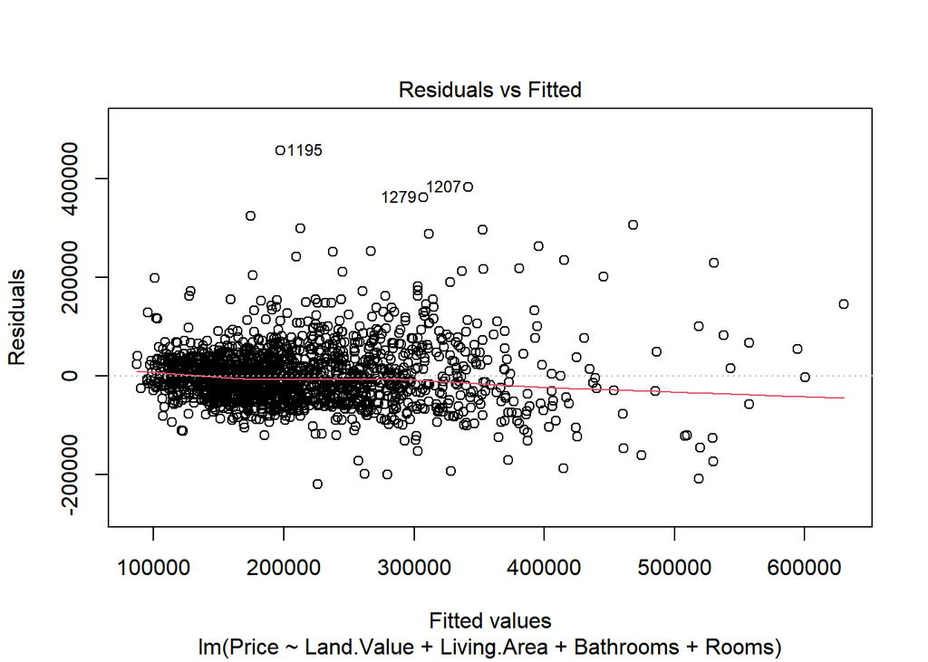

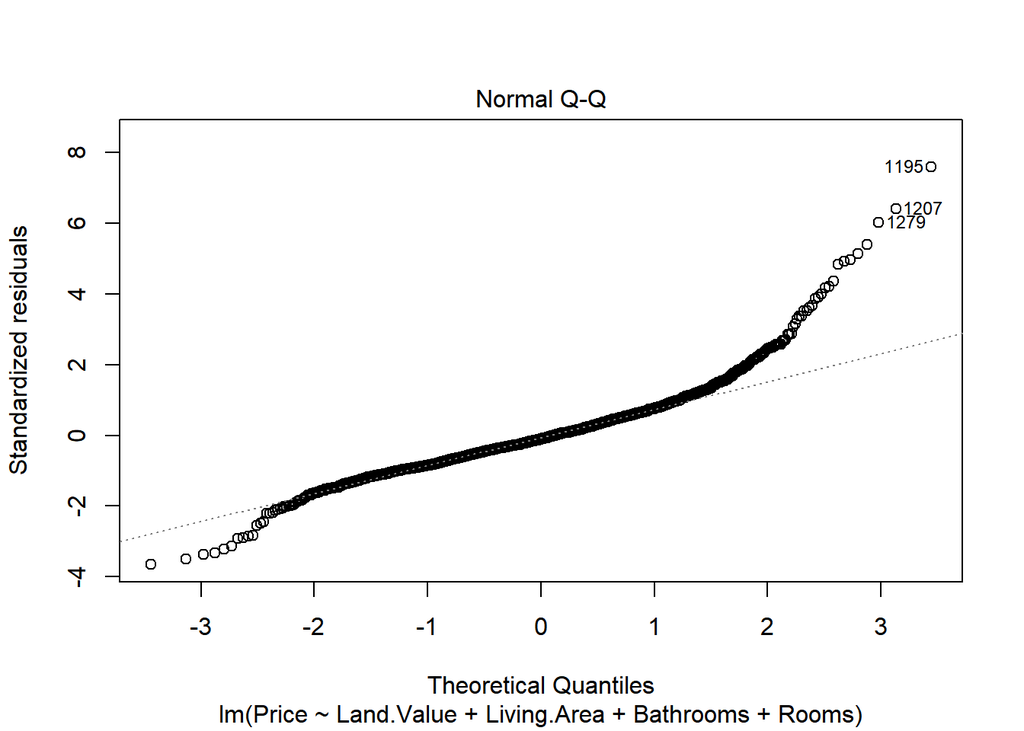

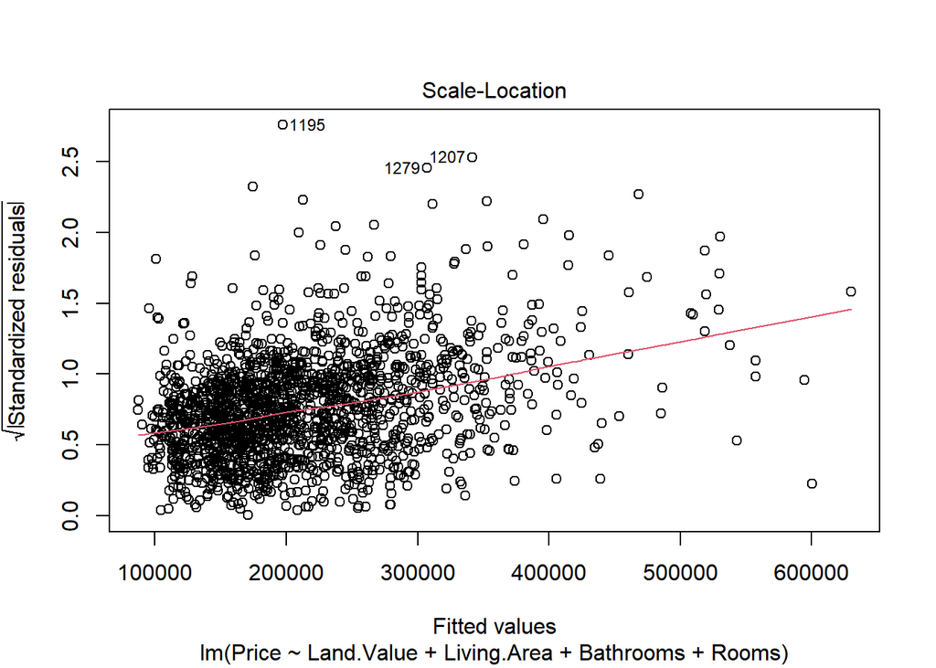

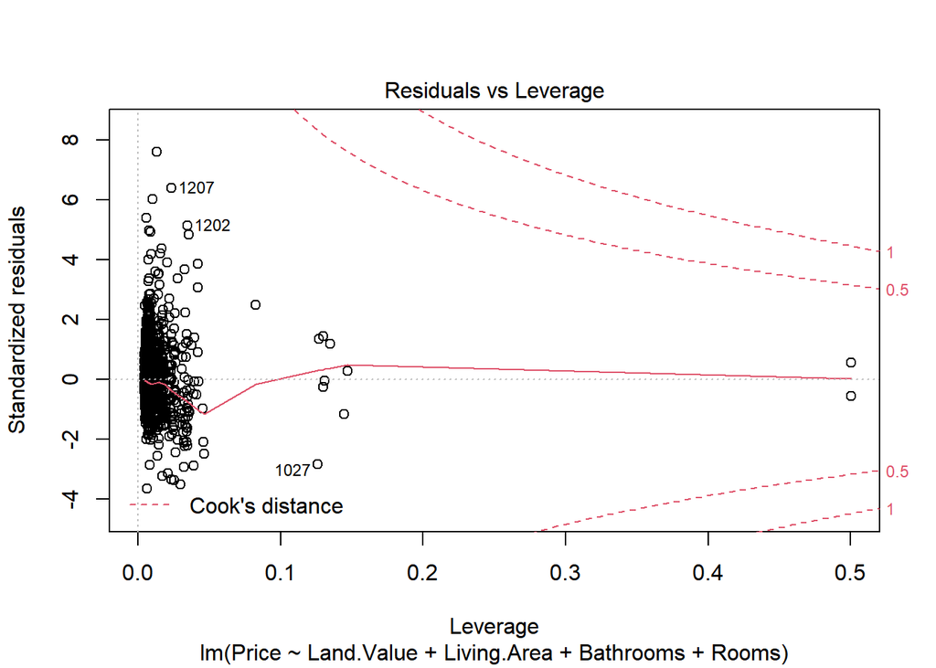

```r
plot(modelReg1)
```

```r
modelReg2<-update(modelReg1, ~. -Rooms)
summary(modelReg2)
```

```
##
## Call:
## lm(formula = Price ~ Land.Value + Living.Area + Bathrooms, data = HP)
##
## Residuals:
##     Min      1Q  Median      3Q     Max
## -218676  -34780   -6004   28300  464106
##
## Coefficients:
##                 Estimate  Std. Error t value             Pr(>|t|)
## (Intercept)  36449.67197  5450.93655   6.687      0.0000000000307 ***
## Land.Value       0.95584     0.04616  20.708 < 0.0000000000000002 ***
## Living.Area     71.00893     3.69160  19.235 < 0.0000000000000002 ***
## Bathrooms1.5   605.56407  4437.33361   0.136               0.8915
## Bathrooms2   25603.15485  5202.53630   4.921      0.0000009419736 ***
## Bathrooms2.5 32292.06265  5484.66552   5.888      0.0000000046983 ***
## Bathrooms3   48811.90798  9869.02259   4.946      0.0000008315425 ***
## Bathrooms3.5 82548.55485 12226.62423   6.752      0.0000000000199 ***
## Bathrooms4   40523.12361 23641.26148   1.714               0.0867 .
## Bathrooms4.5 15285.53485 61440.36902   0.249               0.8036
## ---
## Signif. codes:  0 '***' 0.001 '**' 0.01 '*' 0.05 '.' 0.1 ' ' 1
##
## Residual standard error: 60620 on 1721 degrees of freedom
## Multiple R-squared:  0.6234, Adjusted R-squared:  0.6214
## F-statistic: 316.5 on 9 and 1721 DF,  p-value: < 0.00000000000000022
```

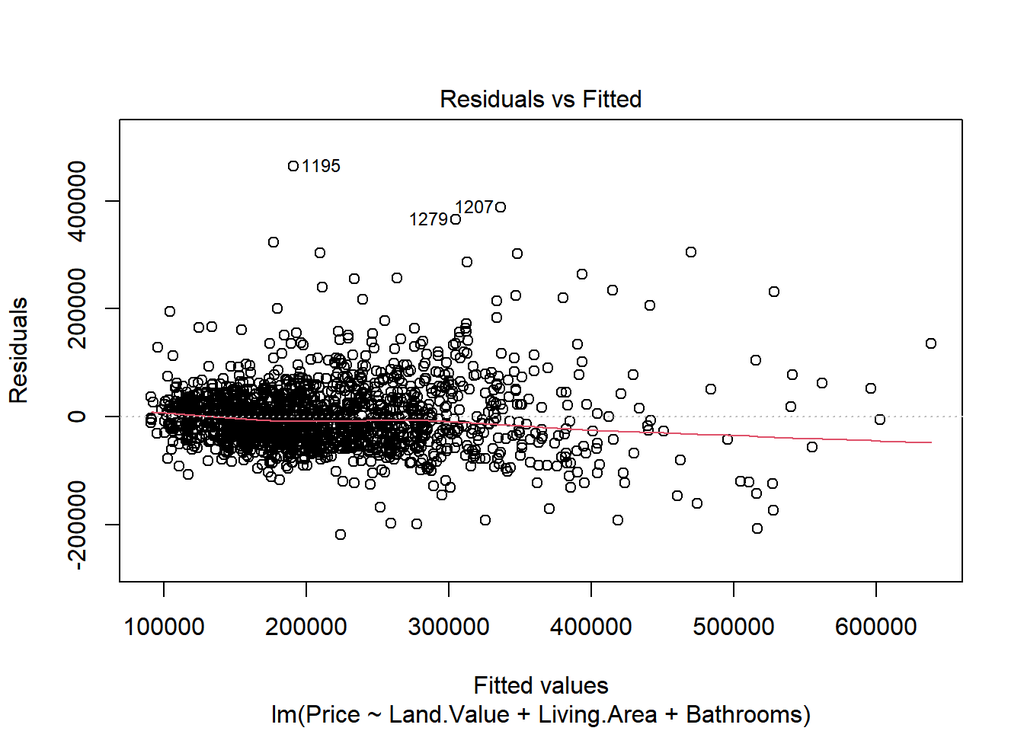

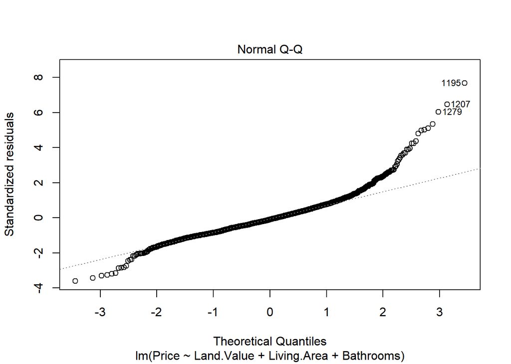

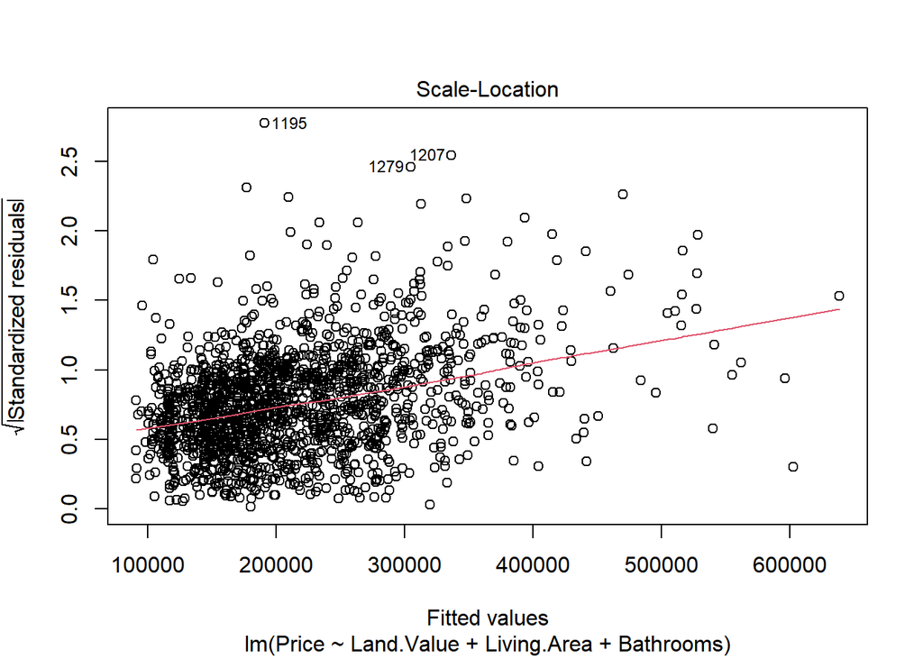

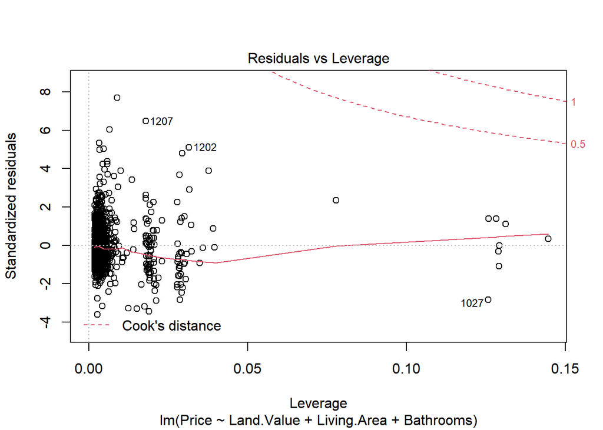

```r
plot(modelReg2)
```

```r
modelReg3<-update(modelReg2, ~. -Bathrooms)
summary(modelReg3)
```

```
##
## Call:
## lm(formula = Price ~ Land.Value + Living.Area, data = HP)
##
## Residuals:
##     Min      1Q  Median      3Q     Max
## -241131  -37208   -6267   28046  465813
##
## Coefficients:
##                Estimate  Std. Error t value             Pr(>|t|)
## (Intercept) 20075.72881  4491.81120   4.469           0.00000835 ***
## Land.Value      0.95713     0.04707  20.333 < 0.0000000000000002 ***
## Living.Area    90.41836     2.65719  34.028 < 0.0000000000000002 ***
## ---
## Signif. codes:  0 '***' 0.001 '**' 0.01 '*' 0.05 '.' 0.1 ' ' 1
##
## Residual standard error: 62100 on 1728 degrees of freedom
## Multiple R-squared:  0.6032, Adjusted R-squared:  0.6027
## F-statistic:  1313 on 2 and 1728 DF,  p-value: < 0.00000000000000022
```

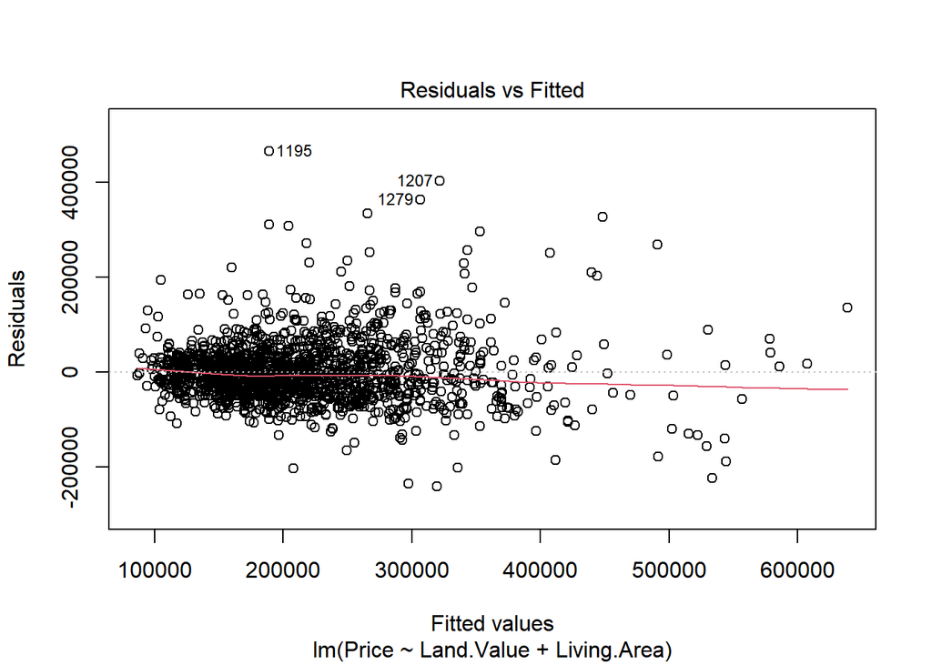

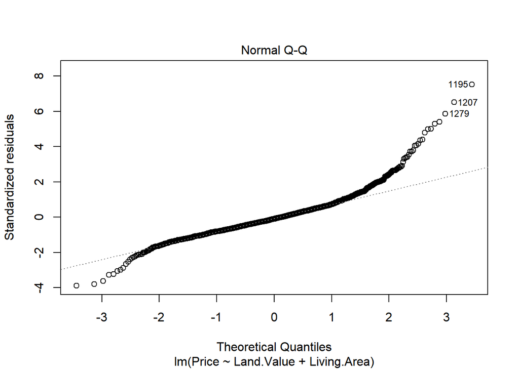

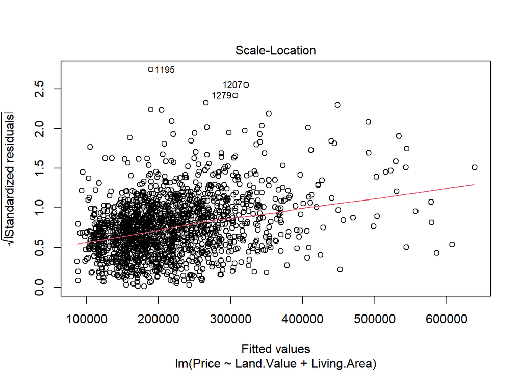

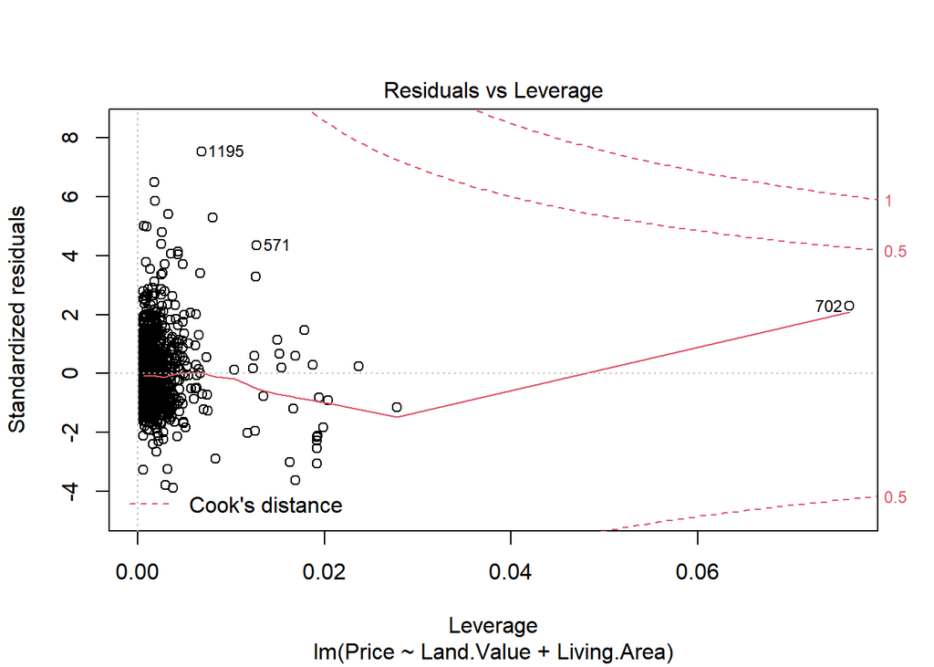

```r
plot(modelReg3)
```

```r
anova(modelReg2, modelReg3)
```

```
## Analysis of Variance Table
##
## Model 1: Price ~ Land.Value + Living.Area + Bathrooms
## Model 2: Price ~ Land.Value + Living.Area
##   Res.Df           RSS Df     Sum of Sq      F                Pr(>F)
## 1   1721 6324003469402
## 2   1728 6663044967528 -7 -339041498126 13.181 < 0.00000000000000022 ***
## ---
## Signif. codes:  0 '***' 0.001 '**' 0.01 '*' 0.05 '.' 0.1 ' ' 1
```

```r
Pred.Price <- predict(modelReg3)
PredHP <- cbind(HP, Pred.Price)
head(PredHP)
```

```
##    Price Lot.Size Waterfront Age Land.Value New.Construct Central.Air Fuel.Type
## 1 132500     0.09         No  42      50000            No          No  Electric
## 2 181115     0.92         No   0      22300            No          No       Gas
## 3 109000     0.19         No 133       7300            No          No       Gas
## 4 155000     0.41         No  13      18700            No          No       Gas
## 5  86060     0.11         No   0      15000           Yes         Yes       Gas
## 6 120000     0.68         No  31      14000            No          No       Gas
##   Heat.Type Sewer.Type Living.Area Pct.College Bedrooms Fireplaces Bathrooms
## 1  Electric    Private         906          35        2          1         1
## 2 Hot Water    Private        1953          51        3          0       2.5
## 3 Hot Water     Public        1944          51        4          1         1
## 4   Hot Air    Private        1944          51        3          1       1.5
## 5   Hot Air     Public         840          51        2          0         1
## 6   Hot Air    Private        1152          22        4          1         1
##   Rooms Pred.Price
## 1     5   149851.4
## 2     6   218006.8
## 3     8   202836.1
## 4     5   213747.4
## 5     3   110384.1
## 6     8   137637.5
```

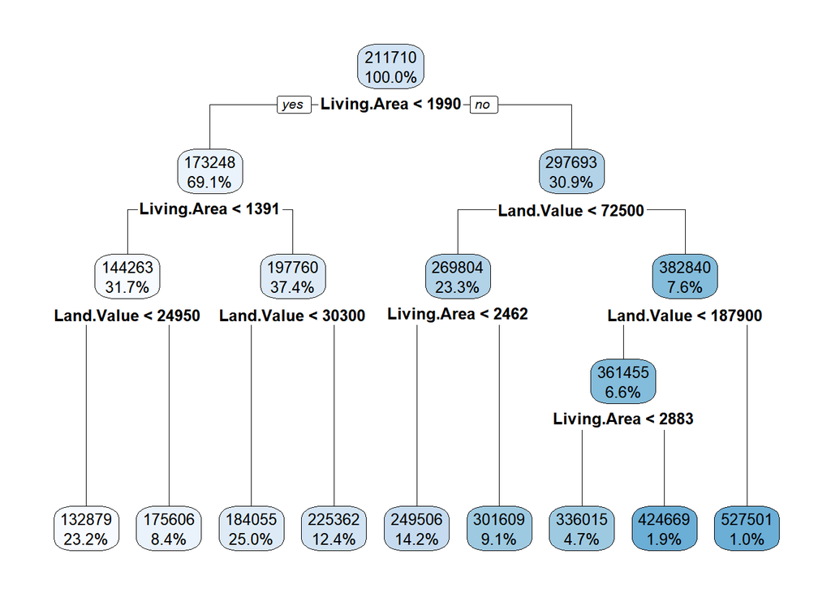

```r
library(rpart)
library(rpart.plot)
modeltree<-rpart(Pred.Price ~., PredHP)
rpart.plot(modeltree, digits=-3)
```

```r
HP[179, 1:16]
```

```
##      Price Lot.Size Waterfront Age Land.Value New.Construct Central.Air
## 179 247000     0.46         No  13      36600            No         Yes
##     Fuel.Type Heat.Type Sewer.Type Living.Area Pct.College Bedrooms Fireplaces
## 179       Gas   Hot Air     Public        2114          64        4          1
##     Bathrooms Rooms
## 179       3.5     8
```

```r
predict(modelReg3, list(Land.Value=36600, Living.Area=2114))
```

```
##        1
## 246251.2
```

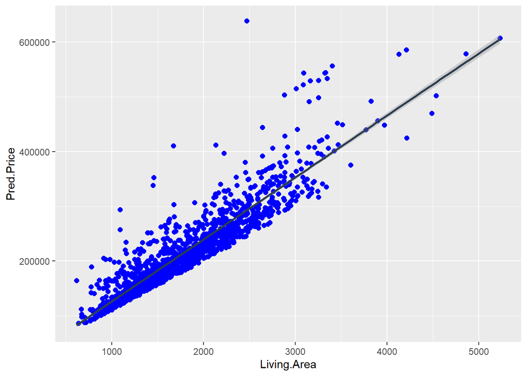

```r
ggplot(PredHP, aes(x=Living.Area, y=Pred.Price)) +
  geom_point(color='blue', size = 2) +
  geom_smooth(method=lm, color='#2C3E50')
```

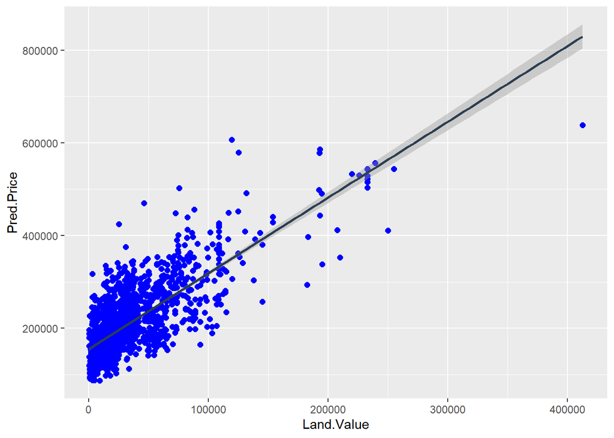

```r
ggplot(PredHP, aes(x=Land.Value, y=Pred.Price)) +
  geom_point(color='blue', size = 2) +
  geom_smooth(method=lm, color='#2C3E50')
```